# Time Series Characteristics

## Time Series Data

A lot of data around us is measured over a span of time.

- Macroeconomic data such as unemployment
- Financial data such as stock prices
- Weather
- Sports

```python
import pandas as pd
import numpy as np
import matplotlib.pyplot as plt
unemployment = pd.read_csv('unemployment_rate.csv', parse_dates=['date'],index_col='date')
nvidia = pd.read_csv('nvda.csv', parse_dates=['Date'], index_col = 'Date')
temp = pd.read_csv('nyc_temp.csv', parse_dates=['date'], index_col='date')
temp['temp_avg'] = (temp.temp_min + temp.temp_max)/2
height = pd.read_csv('olympic_swimmer_height.csv', parse_dates = ['year'], index_col='year')
median_height = height.loc[(height.sport=='Swimming') & (height.sex=='M'),['height']].groupby(['year']).median()
```

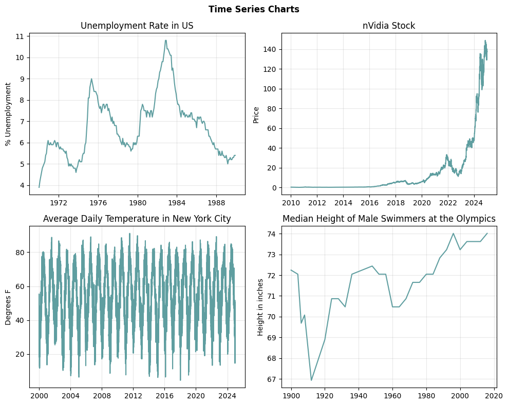

```python
fig, ax = plt.subplots(2, 2, figsize=(10, 8))
fig.suptitle('Time Series Charts', fontsize=12, fontweight='bold')

ax[0,0].plot(unemployment.value, color = 'cadetblue')
ax[0,0].set_title('Unemployment Rate in US')
ax[0,0].set_ylabel('% Unemployment')
ax[0,0].grid(True, alpha = 0.3)

ax[0,1].plot(nvidia.Close_NVDA, color = 'cadetblue')
ax[0,1].set_title('nVidia Stock')
ax[0,1].set_ylabel('Price')
ax[0,1].grid(True, alpha = 0.3)

ax[1,0].plot(temp.temp_avg, color = 'cadetblue')
ax[1,0].set_title('Average Daily Temperature in New York City')
ax[1,0].set_ylabel('Degrees F')
ax[1,0].grid(True, alpha = 0.3)

ax[1,1].plot(median_height, color = 'cadetblue')
ax[1,1].set_title('Median Height of Male Swimmers at the Olympics')
ax[1,1].set_ylabel('Height in inches')
ax[1,1].grid(True, alpha = 0.3)

plt.tight_layout()
plt.show()
```

## Simplifying assumptions

We make some simplifying assumptions about time-series

- Consecutive observations are equally spaced.
- Apply a discrete-time index (even though this may only hold approximately).

## Time Series Patterns

Time Series tend to follow one or more of the following patterns:

1. Trend: A long term increase or decrease in the data. Could be linear, non-linear, and may go from an increasing trend to a decreasing trend.
2. Seasonal: Pattern repeats itself every season. Here season may be period of the year or day of the week. Seasonality is always of a fixed or known frequency.
3. Cycle: Data exhibit rises or falls that are not of a fixed frequency.

To understand these components, let us decompose a time series into trend, seasonality and residuals.

### Components of nVidia’s Stock Price

We will use the daily closing price for nVidia stock from 2010 to 2024. Stock data typically doesn’t have strong seasonality, but we can still identify trends. Period is set to 252 based on the number of trading days in a year.

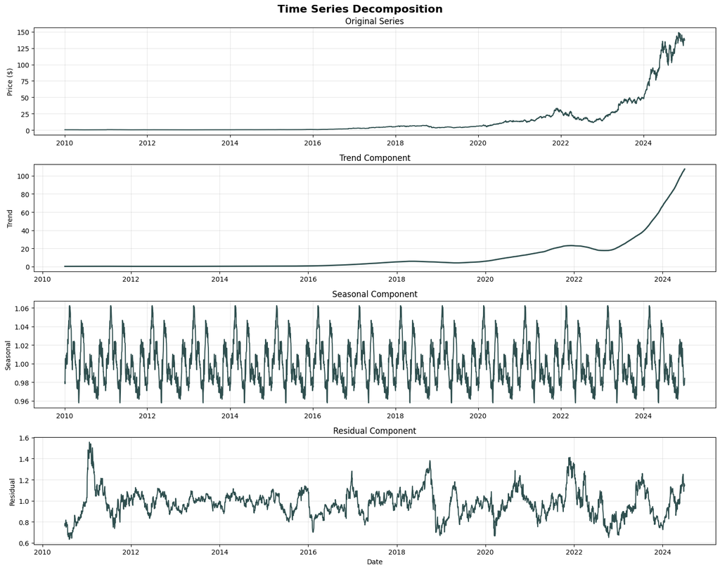

```python
from statsmodels.tsa.seasonal import seasonal_decompose
from statsmodels.tsa.holtwinters import SimpleExpSmoothing
decomposition = seasonal_decompose(nvidia.Close_NVDA, model='multiplicative', period=252) # 252 trading days in a year

fig, axes = plt.subplots(4, 1, figsize=(15, 12))
fig.suptitle('Time Series Decomposition', fontsize=16, fontweight='bold')
# Original data
axes[0].plot(nvidia.index, nvidia.Close_NVDA, color='darkslategray')
axes[0].set_title('Original Series')
axes[0].set_ylabel('Price ($)')
axes[0].grid(True, alpha=0.3)

# Trend component
axes[1].plot(nvidia.index, decomposition.trend, color='darkslategray', linewidth=2)
axes[1].set_title('Trend Component')
axes[1].set_ylabel('Trend')
axes[1].grid(True, alpha=0.3)

# Seasonal component
axes[2].plot(nvidia.index, decomposition.seasonal, color='darkslategray')
axes[2].set_title('Seasonal Component')
axes[2].set_ylabel('Seasonal')
axes[2].grid(True, alpha=0.3)

# Residual component
axes[3].plot(nvidia.index, decomposition.resid, color='darkslategray')
axes[3].set_title('Residual Component')
axes[3].set_xlabel('Date')
axes[3].set_ylabel('Residual')
axes[3].grid(True, alpha=0.3)

plt.tight_layout()
plt.show()
```

### Components of Daily Temperature in New York

Next, we will decompose the time series of the average daily temperature in New York.

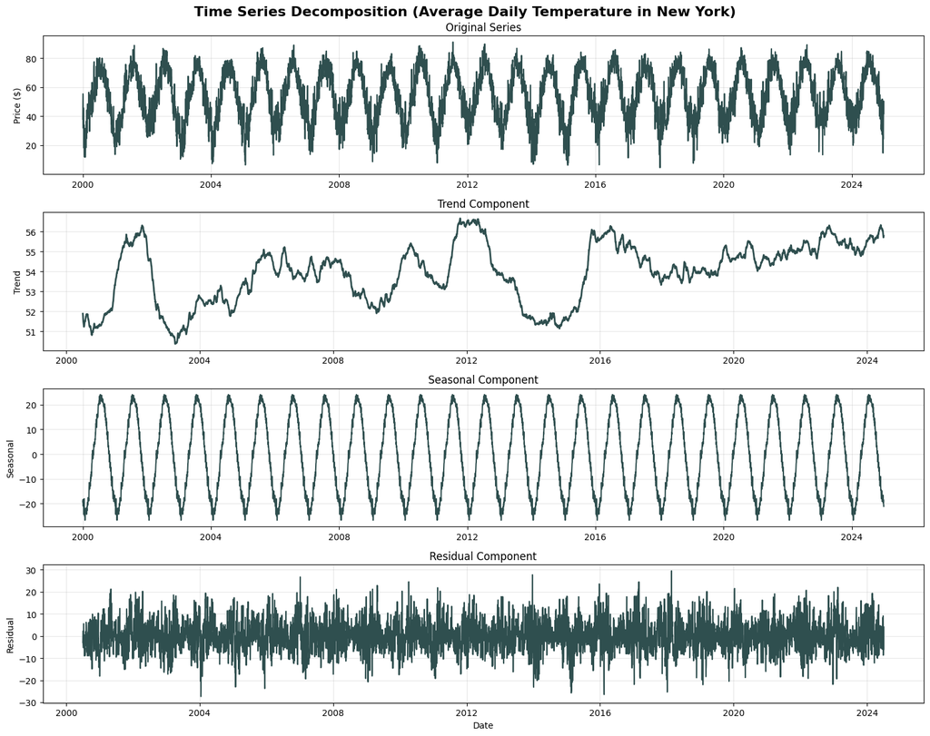

```python
decomposition = seasonal_decompose(temp.temp_avg, model='additive', period=365)

fig, axes = plt.subplots(4, 1, figsize=(15, 12))
fig.suptitle('Time Series Decomposition (Average Daily Temperature in New York)', fontsize=16, fontweight='bold')
# Original data
axes[0].plot(temp.index, temp.temp_avg, color='darkslategray')
axes[0].set_title('Original Series')
axes[0].set_ylabel('Price ($)')
axes[0].grid(True, alpha=0.3)

# Trend component
axes[1].plot(temp.index, decomposition.trend, color='darkslategray', linewidth=2)
axes[1].set_title('Trend Component')
axes[1].set_ylabel('Trend')
axes[1].grid(True, alpha=0.3)

# Seasonal component
axes[2].plot(temp.index, decomposition.seasonal, color='darkslategray')
axes[2].set_title('Seasonal Component')
axes[2].set_ylabel('Seasonal')
axes[2].grid(True, alpha=0.3)

# Residual component
axes[3].plot(temp.index, decomposition.resid, color='darkslategray')
axes[3].set_title('Residual Component')
axes[3].set_xlabel('Date')
axes[3].set_ylabel('Residual')
axes[3].grid(True, alpha=0.3)

plt.tight_layout()
plt.show()
```

## Autocorrelation and Partial Autocorrelation

With things that change over time, the current value is often related to previous values. The extent to which this is true is measured as autocorrelation and partial autocorrelation.

### Autocorrelation

- The Autocorrelation Function (ACF) measures the correlation between the time series and its own lagged values. It captures both direct and indirect effects.
- Helps identify the q (MA) term in ARIMA.
- In an MA(q) process, ACF will cut off after lag q and be near zero afterward.

### Partial Autocorrelation

- The Partial Autocorrelation Function (PACF) measures the correlation between the time series and its lagged values, controlling for the values of all shorter lags.
- Helps identify the p (AR) term in ARIMA.
- In an AR(p) process, PACF will cut off after lag p and be near zero afterward.

We will examine these measures using Monthly International Air Passengers for Ireland.

## Autocorrelation

```python
import pandas as pd
import numpy as np
import matplotlib.pyplot as plt
from statsmodels.graphics.tsaplots import plot_pacf, plot_acf
from statsmodels.tsa.stattools import acf, pacf
```

```python
passengers = pd.read_csv('air_passengers.csv',
                 parse_dates = ['date'], date_format='%Y-%m-%d',
                 index_col='date')
passengers_ireland = passengers.loc[passengers.name =='Ireland',:]
passengers_ireland
```

| date | name | Total | Domestic | International | Total_OS |
| --- | --- | --- | --- | --- | --- |
| 2010-01-01 | Ireland | 1488.034 | 30.502 | 1457.532 | 1522.530 |
| 2010-02-01 | Ireland | 1548.150 | 38.198 | 1509.952 | 1579.746 |
| 2010-03-01 | Ireland | 1865.279 | 44.373 | 1820.906 | 1898.331 |
| 2010-04-01 | Ireland | 1464.440 | 25.856 | 1438.584 | 1468.642 |
| 2010-05-01 | Ireland | 1968.408 | 29.101 | 1939.307 | 1963.063 |
| ... | ... | ... | ... | ... | ... |
| 2018-08-01 | Ireland | 3799.828 | 10.880 | 3788.948 | NaN |
| 2018-09-01 | Ireland | 3391.539 | 8.639 | 3382.900 | NaN |
| 2018-10-01 | Ireland | 3228.463 | 8.243 | 3220.220 | NaN |
| 2018-11-01 | Ireland | 2595.786 | 8.753 | 2587.033 | NaN |
| 2018-12-01 | Ireland | 2554.922 | 6.978 | 2547.944 | NaN |

108 rows × 5 columns

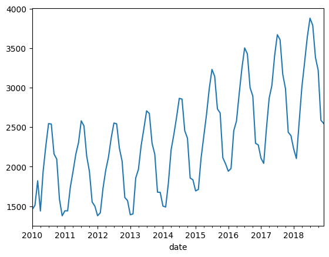

```python
passengers_ireland.International.plot()
plt.show()
```

Spikes in autocorrelation for one period ago indicates a trend while the spike at period 12 indicates seasonality

```python
acf(passengers_ireland.International,nlags = 24)
```

```
array([ 1.        ,  0.88805317,  0.68792206,  0.41916341,  0.13727324,
       -0.05867618, -0.14169668, -0.07118347,  0.10283861,  0.34201522,
        0.5740947 ,  0.72911896,  0.79601632,  0.70058413,  0.51975169,
        0.27779246,  0.03930533, -0.12861188, -0.20313284, -0.14599245,
        0.00186496,  0.20798148,  0.40557947,  0.53603026,  0.59437521])
```

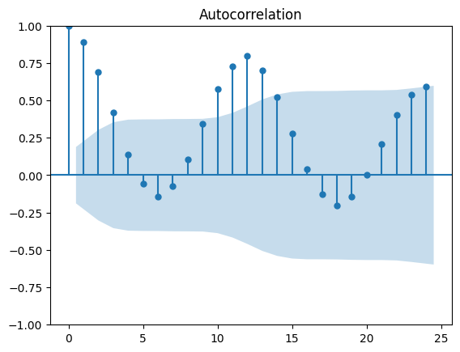

```python
plot_acf(passengers_ireland.International,lags = 24)
plt.show()
```

## Partial Autocorrelation

```python
pacf(passengers_ireland.International,nlags = 24)
```

```
array([ 1.00000000e+00,  8.96352732e-01, -5.21727671e-01, -4.00150791e-01,
       -1.14160937e-01,  4.98369913e-01,  4.61723147e-01,  6.94414940e-01,
        3.49858735e-01, -6.52849040e-03, -7.48877472e-01, -1.86978119e+00,
        4.60606567e-01, -1.86015547e+00,  2.20368365e-01,  4.12148104e-01,
        6.03677677e-01, -5.52184023e-01, -2.17352487e-01, -5.08761948e-01,
        9.78151661e-01, -1.46294683e-01,  2.00717046e+00,  9.80940930e+00,
       -1.87850629e+00])
```

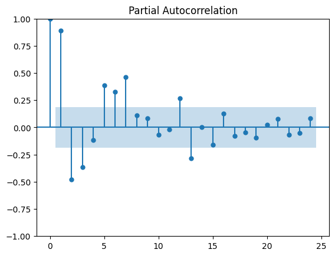

```python
plot_pacf(passengers_ireland.International,lags = 24)
plt.show()
```

### Random Data

Autocorrelations indicate a pattern in the data. This is unlikely to be found in random data.

```python
x0 = np.random.randn(1000)
```

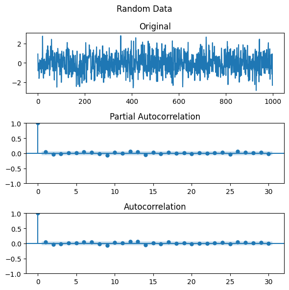

```python
fig, axes = plt.subplots(3, 1, figsize=(6, 6))
fig.suptitle('Random Data')
# Original data
axes[0].plot(x0)
axes[0].set_title('Original')
plot_pacf(x0,ax=axes[1])
plot_acf(x0,ax=axes[2])
plt.tight_layout()
plt.show()
```

## Summary

In this note, we noted that most time series contain a trend, seasonality and noise. The relationship between successive observations can be quantified by measuring autocorrelation.

This file was generated using Python 3.13.5 on Windows 10 with the following libraries: matplotlib 3.10.3, numpy 2.3.1, pandas 2.3.0, statsmodels 0.14.5